# Group 12 - Report - BA Assignment

# MOT122A - Business Analytics Group Assignment

## Overview

### Problem Statement

Capturing the audience’s attention in the current digital landscape is a substantial challenge with the endless content at users’ fingertips. Every minute, 1,800 YouTube videos are posted, amounting to a 360 hour increase in available content on the platform [[1](https://seo.ai/blog/how-many-videos-are-on-youtube)]. As a marketing professional, how do you ensure your video stands out? This challenge is further exacerbated by humans’ ever-decreasing average attention span which, in 2024, was measured at just 8 seconds [[2](https://devrix.com/tutorial/user-attention-span/#:~:text=The%20average%20user%20attention%20span,8%20seconds%20in%20recent%20years)].

Attracting the audience’s attention is challenging enough; sustaining it is yet another. Both aspects are critical for successful marketing campaigns which is why industry professionals such as content creators and product/service marketing teams need to know their audiences, know what keeps them interested, what drives them away, and what levers they can pull to increase their reach. This is where machine learning comes in.

### Task

Develop a machine learning model to classify a video’s trendiness given the video metadata, engagement statistics, and temporal rankings.

### Application

This machine learning model can be leveraged by marketing professionals to predict the likelihood that a given YouTube video will become trendy. This information informs tactical choices in the development process, enabling the professional to optimize video content and publishing strategies to increase the chance of the video becoming trendy. A trendy video subsequently increases the video’s number of impressions which is a typical KPI (key performance indicator) among marketing teams. This, in turn, usually influences engagement metrics, another typical KPI among marketing campaigns and industry professionals.

### Dataset

We are using the dataset from Kaggle - [Trending Youtube Video Statistics (113 Countries)](https://www.kaggle.com/datasets/asaniczka/trending-youtube-videos-113-countries). Top 50 latest trending videos on YouTube across 113 countries. With **daily updates**, this dataset provides comprehensive information about the top trending videos, including daily rankings, movement trends, view counts, likes, comments, and more. We are using a version of the dataset downloaded on 20 February 2025.

## Data Cleaning

### 1. Importing the required libraries

Only use this cells to import all the required libraries. DO NOT import the libraries in any other cells below, it helps with maintaining the code properly and enhances the readability of the code.

Now that we have all the required libraries imported, let’s dive into analyzing the dataset and train a ML model to classify the video as a Trending video or not. First, let’s start by importing the dataset and cleaning it.

#### Import Dataset

This cell imports the raw data. Since the data is too large for `GitHub` we can only use the data in our local system. So, please make sure you update the `filepath` with your own path before proceeding further in the notebook.

```r
# Update this variable with the your own filepath
data_filepath <- "C:/Users/sabes/Desktop/Group Assignment/trending_yt_videos_113_countries.csv"

#Import dataset
yt_df <- read.csv(data_filepath)
```

> *Tip: You can run all the cells at once to get the final model (or) you can import different versions of the dataset at particular sections and run the remainder of the codes. The latter is suggested, because of RStudio’s limited memory capacity. The places where you can import the specific dataset(s) will be marked with `import dataset (optional)` text and the exact dataset that you should be using at that stage.*

### 2. Inspecting the Raw Data

We are just performing an initial check on the raw data. We do not manipulate any data points here as the main aim is to understand the raw data. First, let’s look at the structure of the data.

```r
# Structure of the dataset
str(yt_df)
```

```
## 'data.frame':    2720499 obs. of  18 variables:
##  $ title          : chr  "Jah Prayzah - Mandionei (Official Performance Video)" "Winky D - Siya" "Winky D Fake Love (Official Ai Video)" "Kendrick Lamar's Apple Music Super Bowl Halftime Show" ...
##  $ channel_name   : chr  "Jah Prayzah" "winkyonline" "winkyonline" "NFL" ...
##  $ daily_rank     : int  1 2 3 4 5 6 7 8 9 10 ...
##  $ daily_movement : int  0 0 0 0 45 -1 -1 -1 0 -2 ...
##  $ weekly_movement: int  49 -1 -1 -1 45 -2 -2 42 -2 -4 ...
##  $ snapshot_date  : chr  "2025-02-20" "2025-02-20" "2025-02-20" "2025-02-20" ...
##  $ country        : chr  "ZW" "ZW" "ZW" "ZW" ...
##  $ view_count     : int  640294 1483949 1031541 75930862 4166631 10558534 122104 88610239 220647 535141 ...
##  $ like_count     : int  33578 59662 48158 2735285 64473 203986 8758 3509581 0 26066 ...
##  $ comment_count  : int  6942 10408 6185 161203 3630 8784 446 4820 1107 4229 ...
##  $ description    : chr  "Our first single for 2025\nNot a part of the Ndini Mukudzeyi Album\n\nProduced by: Rodney Beatz\nDirected by: S"| __truncated__ "You can purchase the EP from stores below:\nSPOTIFY - https://open.spotify.com/album/169XgVulpRsny8FPGLkY9s?si="| __truncated__ "You can purch…
##  $ thumbnail_url  : chr  "https://i.ytimg.com/vi/hQGU7Hjr6KA/mqdefault.jpg" "https://i.ytimg.com/vi/Mq0J2Q4I71U/mqdefault.jpg" "https://i.ytimg.com/vi/6YvoX8x6aCw/mqdefault.jpg" "https://i.ytimg.com/vi/KDorKy-13ak/mqdefault.jpg" ...
##  $ video_id       : chr  "hQGU7Hjr6KA" "Mq0J2Q4I71U" "6YvoX8x6aCw" "KDorKy-13ak" ...
##  $ channel_id     : chr  "UCPpVYvHuQSIkQwW1pJhfPrA" "UC9iqkdRHEbX7hwEu9D6J8wg" "UC9iqkdRHEbX7hwEu9D6J8wg" "UCDVYQ4Zhbm3S2dlz7P1GBDg" ...
##  $ video_tags     : chr  "" "" "" "NFL, Football, American Football, sport, sports" ...
##  $ kind           : chr  "youtube#video" "youtube#video" "youtube#video" "youtube#video" ...
##  $ publish_date   : chr  "2025-02-17 00:00:00+00:00" "2025-02-01 00:00:00+00:00" "2025-02-01 00:00:00+00:00" "2025-02-10 00:00:00+00:00" ...
##  $ langauge       : chr  "" "" "" "en" ...
```

As we can see, we have a lot of `chr` datatypes and a few of `int` data type. Next, we will check the summary statistics (like mean, median, min and max of the numerical columns and length, class, mode for non-numerical columns) *[Tip: Check `console` output for better readability]*

```r
# Summary statistics
summary(yt_df)
```

```
##     title           channel_name         daily_rank    daily_movement
##  Length:2720499     Length:2720499     Min.   : 1.00   Min.   :-49.00
##  Class :character   Class :character   1st Qu.:13.00   1st Qu.: -9.00
##  Mode  :character   Mode  :character   Median :26.00   Median : -2.00
##                                        Mean   :25.52   Mean   :  1.74
##                                        3rd Qu.:38.00   3rd Qu.: 10.00
##                                        Max.   :50.00   Max.   : 49.00
##  weekly_movement  snapshot_date        country            view_count
##  Min.   :-49.00   Length:2720499     Length:2720499     Min.   :0.000e+00
##  1st Qu.:  4.00   Class :character   Class :character   1st Qu.:4.865e+05
##  Median : 20.00   Mode  :character   Mode  :character   Median :2.021e+06
##  Mean   : 17.28                                         Mean   :1.275e+07
##  3rd Qu.: 35.00                                         3rd Qu.:1.178e+07
##  Max.   : 49.00                                         Max.   :1.407e+09
##    like_count       comment_count    description        thumbnail_url
##  Min.   :       0   Min.   :     0   Length:2720499     Length:2720499
##  1st Qu.:   16105   1st Qu.:   417   Class :character   Class :character
##  Median :   70872   Median :  1328   Mode  :character   Mode  :character
##  Mean   :  411173   Mean   :  7609
##  3rd Qu.:  374802   3rd Qu.:  4039
##  Max.   :15768055   Max.   :954336
##    video_id          channel_id         video_tags            kind
##  Length:2720499     Length:2720499     Length:2720499     Length:2720499
##  Class :character   Class :character   Class :character   Class :character
##  Mode  :character   Mode  :character   Mode  :character   Mode  :character
##
##
##
##  publish_date         langauge
##  Length:2720499     Length:2720499
##  Class :character   Class :character
##  Mode  :character   Mode  :character
##
##
##
```

Now that we have a glimpse of what raw data we are dealing with, let’s visualize it in the table format to soak in its beauty. *[Tip: Use the arrows to navigate to other columns]*

```r
# First few rows
head(yt_df)
```

```
##                                                                                title
## 1                               Jah Prayzah - Mandionei (Official Performance Video)
## 2                                                                     Winky D - Siya
## 3                                              Winky D Fake Love (Official Ai Video)
## 4                              Kendrick Lamar's Apple Music Super Bowl Halftime Show
## 5                      HIGHLIGHTS Real Madrid 3-1 Man City | Mbappe (3) & Nico Goals
## 6 HIGHLIGHTS Man City 2-3 Real Madrid | Haaland (2), Mbappe, Diaz & Bellingham Goals
##   channel_name daily_rank daily_movement weekly_movement snapshot_date country
## 1  Jah Prayzah          1              0              49    2025-02-20      ZW
## 2  winkyonline          2              0              -1    2025-02-20      ZW
## 3  winkyonline          3              0              -1    2025-02-20      ZW
## 4          NFL          4              0              -1    2025-02-20      ZW
## 5     Man City          5             45              45    2025-02-20      ZW
## 6     Man City          6             -1              -2    2025-02-20      ZW
##   view_count like_count comment_count
```

[output cut: 41 more lines]

Now, it’s time to understand how many rows and columns we have in the raw data. Trust us, this step is as important as every other steps. It might not seem like an great insight right now, but if and when we have to merge this dataset with another, the original dimensions will come in handy. And after data pre-processing, later on in this report, we will compare the final model training dataset with the raw data it as this is a good practice.

```r
# Dimensions of the dataset
dim(yt_df)
```

```
## [1] 2720499      18
```

```r
# Create a classification of columns as numerical or non-numerical
column_types <- sapply(yt_df, is.numeric)

# Extract numerical and non-numerical column names
numerical_columns <- names(column_types[column_types == TRUE])
non_numerical_columns <- names(column_types[column_types == FALSE])

# Print grouped column names
cat("Numerical Columns:\n")
```

```
## Numerical Columns:
```

```r
cat(numerical_columns, sep = "\n")
```

```
## daily_rank
## daily_movement
## weekly_movement
## view_count
## like_count
## comment_count
```

```r
cat("\nNon-Numerical Columns:\n")
```

```
##
## Non-Numerical Columns:
```

```r
cat(non_numerical_columns, sep = "\n")
```

```
## title
## channel_name
## snapshot_date
## country
## description
## thumbnail_url
## video_id
## channel_id
## video_tags
## kind
## publish_date
## langauge
```

With 18 columns, not all of them will be relevant for predicting whether a YouTube video becomes trendy or not. But at first-sight the following columns are worth diving deeper into:

daily_rank: This is the position a video has at a given day. The ranking ranges from 1-50, in which 1 is the highest rank and 50 the lowest. The ranking is done of all videos within a country (a total of 113 countries in the dataset).

daily_movement: This shows how much movement in ranking a video had at a given day. Movement is bounded between -49 to +49.

weekly_moment: Similar to `daily_movement` but then movement measured within a single week. Again bounded between -49 to +49.

view_count: The amount of views a video has had, which is one of the primary KPIs for marketing campaigns and content creators.

Most industry professionals are also very interested in the audience’s interaction with the content and engagement metrics track this relationship. Our dataset contains a few columns which are well-suited to be part of engagement metrics. Here they are:

like_count: This is the total likes a video has received. It is also an important KPI and might become part of an engagement metric variable later on in the analysis.

comment_count: Similar to `like_count` but then done with regards to comments per video.

**Summary of insights gained:**

1. We have 2,720,499 rows and 18 columns in our dataset
2. 12 `char` (non-numerical) columns and 6 `int` (numerical) columns
3. The `int` columns seems to be properly formatted (i.e. without any `str` in between)
4. At first sight, interesting columns for predicting trendiness are `daily_rank`, `daily_movement`, `weekly_movement`, and `view_count`. For engagement metrics columns `like_count` and `comment_count` are relevant.

### 3. Data Pre-Processing

In this step, we will clean the raw data as much as possible, so that it is Exploratory Data Analysis (EDA) ready. First we start with making sure all the column have appropriate datatypes (like `date` type values in `snapshot_date` column).

#### 3.1. Standardizing Column Names and Removing Duplicate Values

Let’s define a user-defined function (`udf`) to do the initial cleaning of the dataset. The function will:

   `kind` : Only one unique value (Youtube video).

   `description` : A large number of blank/null values and converting the description column to numeric with Natural Language Processing (NLP) would be complex.

   `channel_name` , `channel_id` : Minimal contribution to trendiness.

   `thumbnail_url`, `video_id` : No contribution to trendiness.

```r
clean_data <- function(df){
  # Standardize column names
  cleaned_data <- df %>% rename_all(tolower) %>% rename_all(str_replace_all, pattern = " ", replacement = "_")
  # Remove duplicate rows
  df <- df %>% distinct()
  # Dropping unnecessary columns
  df <- df %>% select(-c(channel_name, description, thumbnail_url, kind, video_id, channel_id, langauge))

  return(df)
}
```

*Usually, it is a good practice to keep a copy of your dataset at the end of every junction (or major step), but due to the memory constraints of RStudio, we are going to keep updating the same dataset until the end.*

```r
yt_df <- clean_data(yt_df)
```

As you can see, the column names are standardized with this format (`small_case`) and we have also removed duplicate columns. Our dataset didn’t have any duplicate values, for which we are very grateful.

#### 3.2. Tidy up the non-numerical columns

The non-numerical columns tend to have special characters (like $, %, etc.) that might not be useful for classifying when a video will become trendy. Also, non-numerical columns might contain some ASCII or Unicode characters as well (such as `"\n"`) that might be interfering with the readability and analysis of the values. So, it’s better to treat them by removing them from our dataset.

```r
clean_character_columns <- function(df) {
  df <- df %>%
    mutate(across(where(is.character), ~ {
      cleaned_text <- str_squish(str_replace_all(., "\\p{C}+", ""))
      ifelse(cleaned_text == "", NA, cleaned_text)
    }))
  return(df)
}
```

```r
yt_df <- clean_character_columns(yt_df)
```

Here, the function `clean_character_columns` checks if the column is of type `character` and removes all the Unicode chars (such as `"\n","\r","\t"`). Finally, it trims the leading, trailing and extra spaces with the `str_squish(.)` function.

#### 3.3. Null Value Treatment

Now, it’s time to treat the null values. First, let’s define a `udf` to analyse the data and fetch the number of null values present in each column.

```r
analyze_columns <- function(df) {
  calculate_mode <- function(x) {
    unique_x <- unique(na.omit(x))
    tabulated <- tabulate(match(x, unique_x))
    unique_x[which.max(tabulated)]
  }
  # Create summary statistics for each column
  summary_table <- data.frame(
    `column_type` = sapply(df, typeof),
    `number_of_nulls` = sapply(df, function(x) sum(is.na(x))),
    `%_nulls` = sapply(df, function(x) round(sum(is.na(x)) / length(x) * 100, 2)),
    `mean` = sapply(df, function(x) if (is.numeric(x)) round(mean(x, na.rm = TRUE), 2) else 0),
    `median` = sapply(df, function(x) if (is.numeric(x)) round(median(x, na.rm = TRUE), 2) else 0),
    `min` = sapply(df, function(x) if (is.numeric(x)) round(min(x, na.rm = TRUE), 2) else 0),
    `max` = sapply(df, function(x) if (is.numeric(x)) round(max(x, na.rm = TRUE), 2) else 0),
    `mode` = sapply(df, function(x) if (is.numeric(x) | is.character(x) | is.factor(x)) calculate_mode(x) else "N/A"), stringsAsFactors = FALSE
  )
  return(summary_table)
}
```

```r
null_df <- analyze_columns(yt_df)
print(null_df)
```

```
##                 column_type number_of_nulls X._nulls        mean  median min
## title             character               0     0.00        0.00       0   0
## daily_rank          integer               0     0.00       25.52      26   1
## daily_movement      integer               0     0.00        1.74      -2 -49
## weekly_movement     integer               0     0.00       17.28      20 -49
## snapshot_date     character               0     0.00        0.00       0   0
## country           character               0     0.00        0.00       0   0
## view_count          integer               0     0.00 12749584.43 2021174   0
## like_count          integer               0     0.00   411172.54   70872   0
## comment_count       integer               0     0.00     7608.75    1328   0
## video_tags        character          901279    33.13        0.00       0   0
## publish_date      character               0     0.00        0.00       0   0
##                        max
## title                    0
## daily_rank              50
## daily_movement          49
## weekly_movement         49
## snapshot_date            0
## country                  0
## view_count      1407108038
## like_count        15768055
## comment_count       954336
## video_tags               0
## publish_date             0
##                                                                                                                                                                                                        mode
## title                                                                                                     Cool Items!🥰 New Gadgets, Smart Appliances, Kitchen Tools Utensils, Home Cleaning, Beauty #shorts
## daily_rank                                                                                                                                                                                               49
## daily_movement                                                                                                                                                                                            0
## weekly_movement                                                                                                                                                                                          49
## snapshot_date                                                                                                                                                                                    2024-03-16
## country                                                                                                                                                                                                  RU
## view_count                                                                                                                                                                                                0
## like_count                                                                                                                                                                                                0
## comment_count                                                                                                                                                                                             0
## video_tags      Stokes twins, Mrbeast, Fede, mark rober, Airrack, Ryan Trahan, Dhar mann, Royalty family, Jordan matter, Unspeakable, Preston, Ben azelart, Brent Rivera, Jeremy Hutchins, Lexi Rivera, Amp
## publish_date                                                                                                                                                                      2024-12-22 00:00:00+00:00
```

As visible in the table, only the column `video_tags` has null values in them—almost 1 million of them. We cannot treat them with any common values, since they are dependent on the video itself (i.e. each record). We can drop the rows that have null values, but we will decide this during our feature selection step to ensure we are not losing any valuable data.

#### 3.4. Dropping Unnecessary columns

We will do preliminary feature engineering by dropping unnecessary columns and columns that might not be useful based on the subject knowledge. Basic conditions for determining not-so-useful columns are:

1. Columns with more than 75% null values
2. Columns with only 1 unique values
3. Entire column/row being null

Now, let’s check the number of unique values and if there are columns with only a singular unique value we will drop them.

```r
check_unique_values <- function(df) {
  unique_counts <- sapply(df, function(col) length(unique(col)))
  return(cbind(Unique_Values = unique_counts))
}
```

```r
unique_values_table <- check_unique_values(yt_df)
print(unique_values_table)
```

```
##                 Unique_Values
## title                  216231
## daily_rank                 50
## daily_movement             99
## weekly_movement            99
## snapshot_date             481
## country                   113
## view_count            1426586
## like_count             854054
## comment_count           89809
## video_tags             109926
## publish_date             2784
```

Okay, there are no columns with a singular unique value so let’s continue.

### 4. Export the Cleaned Data (Optional)

This function will export the cleaned data into a `.csv` file into the same path from where you have imported the dataset and with a suffix [`_cleaned`] to the original name.

```r
# export_data <- function(df, input_filepath){
#  output_filepath <- sub(".csv","_cleaned.csv",input_filepath)
#  write.csv(df, output_filepath, row.names = FALSE)
#}
```

```r
# export_data(yt_df, data_filepath)
```

## Exploratory Data Analysis

In this step of the analysis, the aim is to gain a deeper understanding of the data so we can identify obvious errors, missing data, recognize potential patterns, as well as spot outliers.

## 1. Univariate Analysis

#### Import Dataset (Optional)

```r
# Update this variable with the your own filepath
# data_filepath <- "./dataset/trending_yt_videos_113_countries_cleaned.csv"

#Import dataset
# yt_df <- read.csv(data_filepath)
```

The first step in EDA is “`Univariate analysis`” which - in a nutshell - means we will analyze each variable separately. This gives an in-depth understanding of all the variables and is an important step. To put it in car terms: *without knowing what each screw and bolt does, you cannot possibly build a car or repair it.*

#### 1.1. Numerical Columns

```r
analyze_numerical <- function(df) {
  numerical_cols <- names(df)[sapply(df, is.numeric)]

  for (col in numerical_cols) {
    cat("\nColumn Name: ", col, "\n")
    print(summary(df[[col]]))
    cat("Skewness:", e1071::skewness(df[[col]], na.rm = TRUE), "\n")
    cat("Kurtosis:", e1071::kurtosis(df[[col]], na.rm = TRUE), "\n")
    print("-------------------------------------------------------")

    # Visualizations
    pic_1 <- ggplot(df, aes(x = .data[[col]])) +
      geom_histogram(aes(y = ..density..), bins = 30, fill = "blue", alpha = 0.5) +
      geom_density(color = "red") +
      ggtitle(paste("Histogram of", col))

    pic_2 <- ggplot(df, aes(y = .data[[col]])) +
      geom_boxplot(fill = "orange", alpha = 0.5) +
      ggtitle(paste("Boxplot of", col))

    print(pic_1)
    print(pic_2)
  }
}
```

Please be patient when running the below code chunk—it will take a few minutes. In the meantime, think of all the great visuals that it will give you!

```r
analyze_numerical(yt_df)
```

```
##
## Column Name:  daily_rank
##    Min. 1st Qu.  Median    Mean 3rd Qu.    Max.
##    1.00   13.00   26.00   25.52   38.00   50.00
## Skewness: -0.001207918
## Kurtosis: -1.201403
## [1] "-------------------------------------------------------"
```

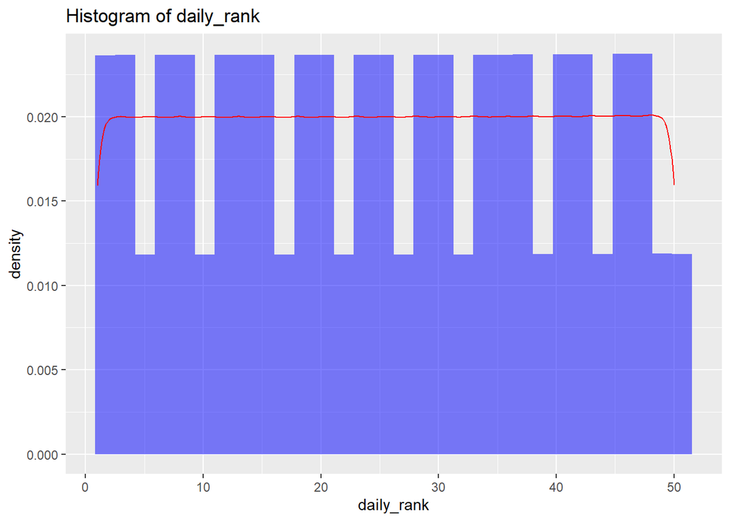

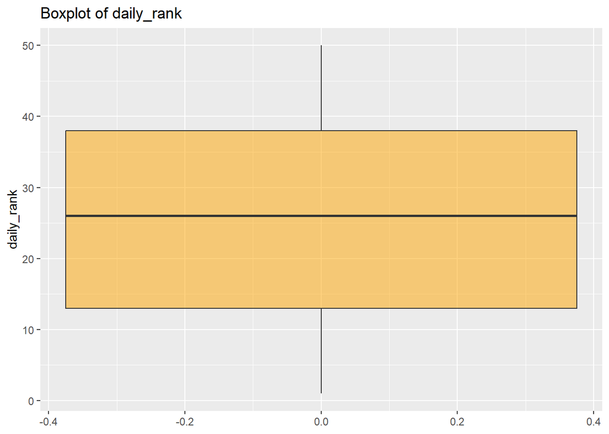

```
##
## Column Name:  daily_movement
##    Min. 1st Qu.  Median    Mean 3rd Qu.    Max.
##  -49.00   -9.00   -2.00    1.74   10.00   49.00
## Skewness: 0.6642895
## Kurtosis: 0.2162377
## [1] "-------------------------------------------------------"
```

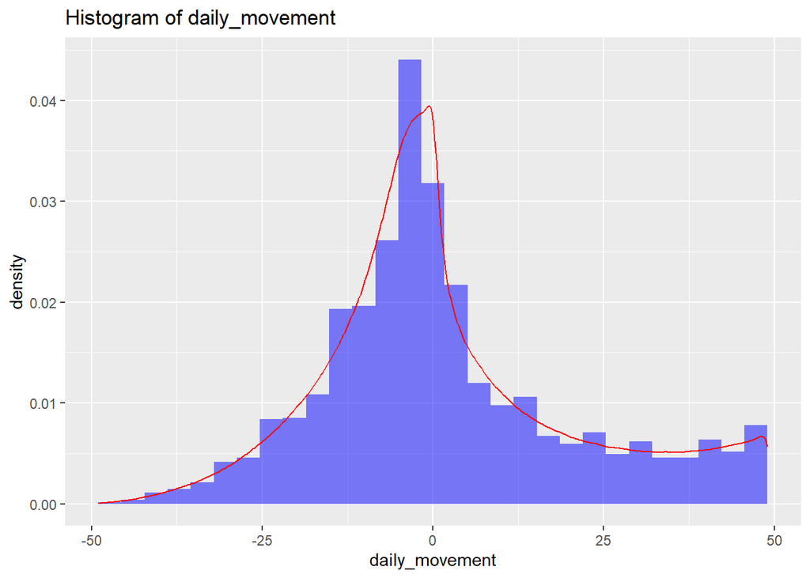

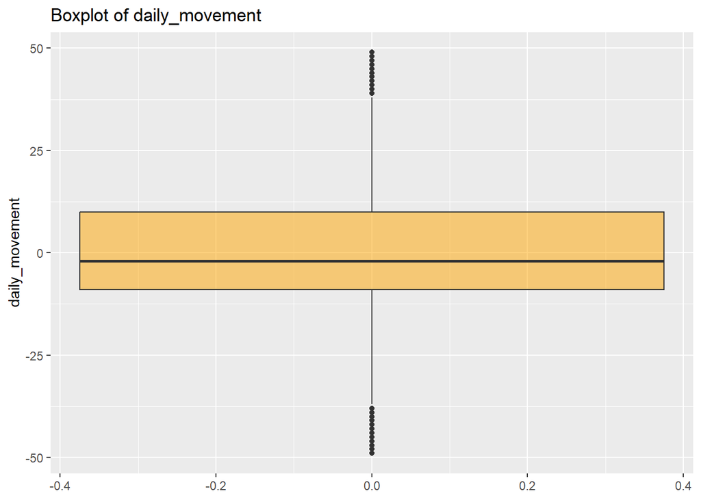

```
##
## Column Name:  weekly_movement
##    Min. 1st Qu.  Median    Mean 3rd Qu.    Max.
##  -49.00    4.00   20.00   17.28   35.00   49.00
## Skewness: -0.7052244
## Kurtosis: -0.1449288
## [1] "-------------------------------------------------------"
```

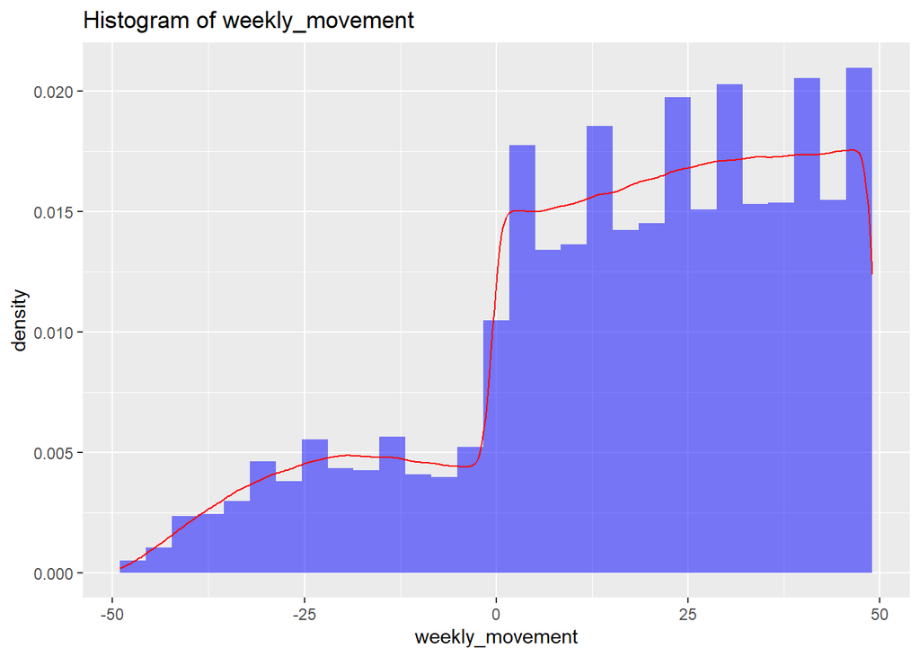

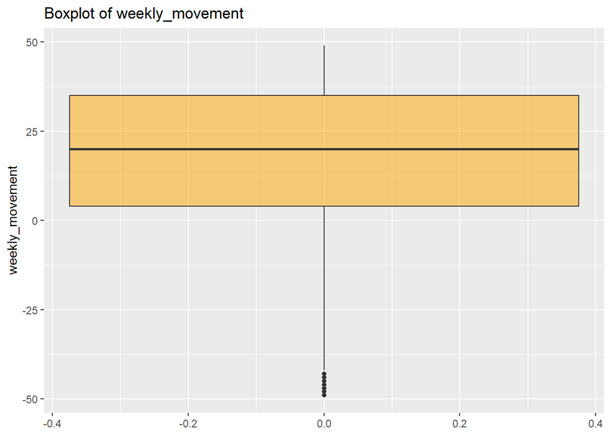

```
##
## Column Name:  view_count
##      Min.   1st Qu.    Median      Mean   3rd Qu.      Max.
## 0.000e+00 4.865e+05 2.021e+06 1.275e+07 1.178e+07 1.407e+09
## Skewness: 6.131736
## Kurtosis: 146.4271
## [1] "-------------------------------------------------------"
```

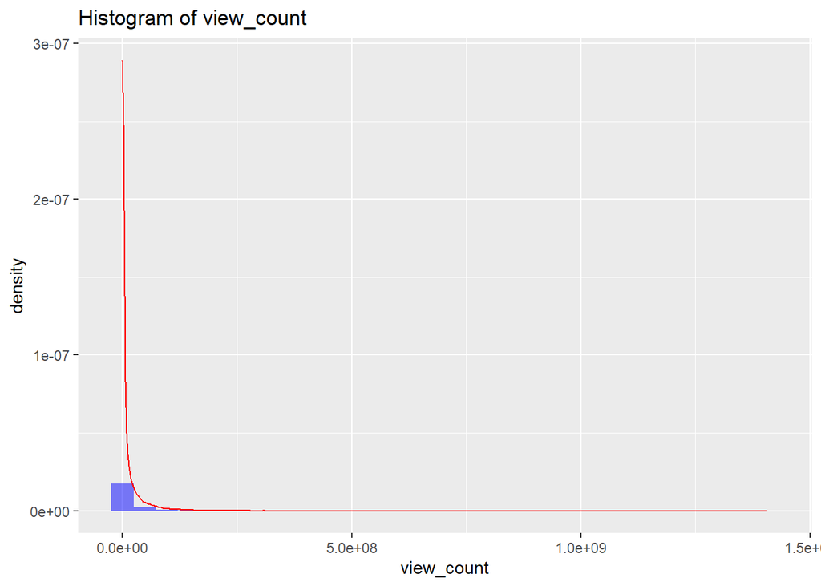

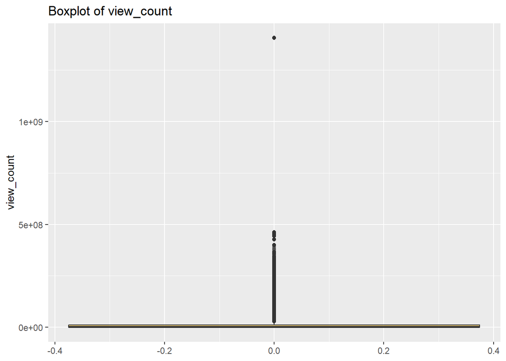

```
##
## Column Name:  like_count
##     Min.  1st Qu.   Median     Mean  3rd Qu.     Max.
##        0    16105    70872   411173   374802 15768055
## Skewness: 4.61904
## Kurtosis: 29.28157
## [1] "-------------------------------------------------------"
```

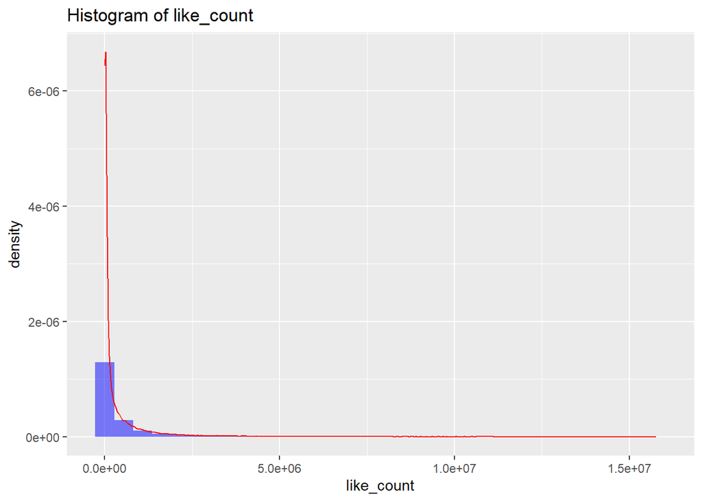

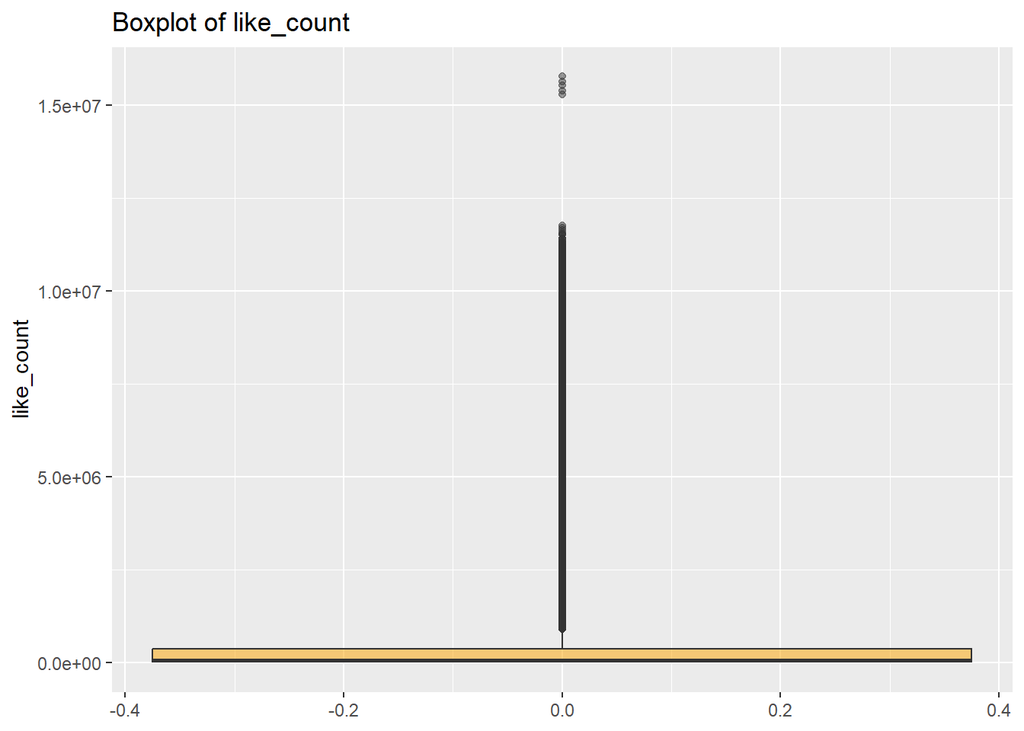

```
##
## Column Name:  comment_count
##    Min. 1st Qu.  Median    Mean 3rd Qu.    Max.
##       0     417    1328    7609    4039  954336
## Skewness: 13.47312
## Kurtosis: 269.5262
## [1] "-------------------------------------------------------"
```

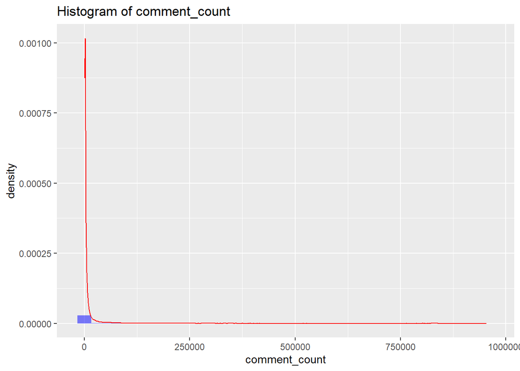

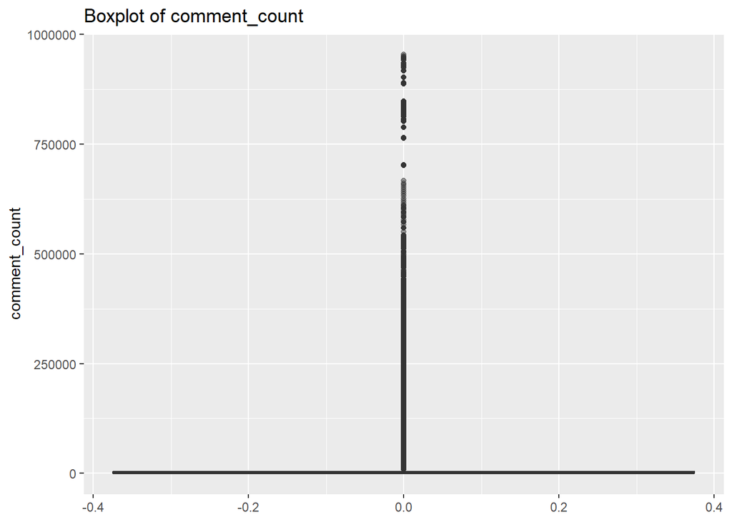

**Abnormalities Numerical Variables**

*Outliers:* The boxplots reveal the presence of outliers in `daily_movement`, `weekly_movement`, `view_count`, `like_count`, and `comment_count`. These outliers indicate extreme values that deviate significantly from the rest of the data. In the context of view, like, and comment counts, outliers might represent exceptionally popular or trendy content.

**Insights Numerical Variables**

For a more detailed overview of analysis per numerical variable and corresponding plot, please see the table below.

[output not shown]

#### 1.2. Non-Numeric Columns

- For `text data`, the function will calculate the most commonly appearing words in the `title` and `video_tags` columns in the `top 10%` of the videos.
- Top 10% - based on `daily_rank`, `daily_movement` and `weekly_movement`. We merge the resultant vectors into one while removing the common words between the 2 techniques. We also correct the spelling using the `hunspell` library to ensure we have words which are meaningful.
- Further in the analysis, we can use this result as a feature to train the model - to be one of the factors that determine the trendliness of the video.

```r
stopwords_list <- stopwords("en")

tokenize <- function(text) {
  words <- unlist(str_extract_all(tolower(text), "\\b\\w+\\b"))
  words <- words[!(words %in% stopwords_list) & nchar(words) > 4 & !grepl("^\\d+$", words)]
  return(words)
}
```

```r
get_top_words <- function(df, ranking_type) {
  if (tolower(ranking_type) == "rank") {
    threshold <- quantile(df$daily_rank, 0.1, na.rm = TRUE)
    top_videos <- df %>% filter(daily_rank <= threshold)
  } else if (tolower(ranking_type) == "movement") {
    threshold_daily <- quantile(df$daily_movement, 0.1, na.rm = TRUE)
    threshold_weekly <- quantile(df$weekly_movement, 0.1, na.rm = TRUE)
    top_videos <- df %>% filter(daily_movement <= threshold_daily | weekly_movement <= threshold_weekly)
  } else {
    stop("Invalid ranking_type. Use 'rank' or 'movement'.")
  }

  # Ignore NA values
  top_videos <- top_videos %>% drop_na(title, video_tags)

  # Process title words
  title_words <- unlist(strsplit(top_videos$title, " ")) %>% tokenize()
  title_word_counts <- sort(table(title_words), decreasing = TRUE)

  # Process video tags words
  tag_words <- unlist(strsplit(top_videos$video_tags, " ")) %>% tokenize()
  tag_word_counts <- sort(table(tag_words), decreasing = TRUE)

  return(list(
    names(title_word_counts)[1:25],
    names(tag_word_counts)[1:25]
  ))
}
```

```r
normalize_word <- function(word) {
  word <- tolower(word)  # Convert to lowercase
  word <- gsub("[- ]", "", word)  # Remove hyphens and spaces
  return(word)
}
```

```r
correct_spelling <- function(words) {
  words <- unique(sapply(words, normalize_word))  # Normalize words first
  corrected_words <- unique(unlist(sapply(words, function(word) {
    suggestions <- hunspell_suggest(word)
    if (length(suggestions) > 0) {
      return(suggestions[[1]][1])  # Pick the first suggestion
    } else {
      return(word)  # Keep original word if no suggestion available
    }
  })))
  return(sort(corrected_words))
}
```

```r
merge_word_tuples <- function(tuple1, tuple2) {
  title_words_combined <- unique(c(tuple1[[1]], tuple2[[1]]))
  tag_words_combined <- unique(c(tuple1[[2]], tuple2[[2]]))

  return(list(
    correct_spelling(title_words_combined),
    correct_spelling(tag_words_combined)
  ))
}
```

```r
common_words_list_rank <- get_top_words(yt_df, "rank")
common_words_list_movement <- get_top_words(yt_df, "movement")


final_results <- merge_word_tuples(common_words_list_rank, common_words_list_movement)
final_title_words <- final_results[[1]]
final_tag_words <- final_results[[2]]

print(paste("Final Title:", length(final_title_words), toString(final_title_words)))
```

```
## [1] "Final Title: 27 angle, Barcelona, challenge, chaser, clowns, episodes, finale, firs, funny, grans, highlights, league, Madrid, Manchester, mine craft, move, musics, official, resume, season, shirts, Short, skidding, toiler, trailers, videos, word"
```

```r
print(paste("Final Tags:", length(final_tag_words), toString(final_tag_words)))
```

```
## [1] "Final Tags: 29 alum, animation, cash, challenge, comely, family, football, funny, highlights, latest, league, Madrid, mine craft, move, movie, musics, NATO, Nigerian, official, rank, resume, rival, shirts, sport, ticktock, trailers, video, videos, you tube"
```

Now, we have 2 lists of words that we can use to introduce a synthetic column that, in turn, can be used as a feature to train the model.

There are also a few columns that seem to be irrelevant in helping our model predict trendiness of a video. These are: `channel_name`, `country`, `description`, `thumbnail_url`, `kind`, `video_id`, `channel_id`, `language.`

The variable `language` had a lot of empty values, and different type of values e.g.: “zh-TW”, or “ja”,or “en-US”. There are even 2280084 values “missing” which are instances in which the language of the video was not recognized. This is too much so we decided to not include this variable.

### 2. Bivariate Analysis

#### 2.1. Country and video trendiness

Let us take a look at the `country` column, as it may yield interesting geographical insights into the trendiness of a video. Initially, this column uses ISO2 country codes, which are not very readable. For clarity, we generate a new column that maps these codes to their full country names.

```r
yt_df$full_country_name <- countrycode(
  sourcevar = yt_df$country,
  origin = "iso2c",
  destination = "country.name",
  warn = FALSE
)

unique_countries <- unique(yt_df$full_country_name)
print(unique_countries[0:5])
```

```
## [1] "Zimbabwe"     "South Africa" "Yemen"        "Vietnam"      "Venezuela"
```

```r
summary(unique_countries)
```

```
##    Length     Class      Mode
##       113 character character
```

After creating this new `full_country_name` column, we observe that the dataset includes videos from 113 distinct countries. This diversity provides a good opportunity to analyze country-level differences in video trendiness.

To begin, we group the dataset by country and count the number of videos per country to understand how frequently each appears in the data.

```r
grouped_df <- yt_df%>% group_by(country)
country_counts <- grouped_df%>% summarise(count = n())
print(country_counts)
```

```
## # A tibble: 113 × 2
##    country count
##    <chr>   <int>
##  1 AE      24095
##  2 AL      24064
##  3 AM      24072
##  4 AR      24096
##  5 AT      24109
##  6 AU      24114
##  7 AZ      24066
##  8 BA      24067
##  9 BD      23875
## 10 BE      24074
## # ℹ 103 more rows
```

```r
summary(country_counts)
```

```
##    country              count
##  Length:113         Min.   :23874
##  Class :character   1st Qu.:24065
##  Mode  :character   Median :24071
##                     Mean   :24075
##                     3rd Qu.:24090
##                     Max.   :24159
```

```r
#ungrouping if wanted
#df_ungrouped <- grouped_df %>% ungroup()
```

To delve deeper, we calculate the median daily rank for each country. Since for now a lower daily rank indicates higher trendiness, this measure helps us identify which countries tend to produce trendier content. To maintain clarity and focus on meaningful insights, we narrow our analysis to the top 10% of countries with the lowest median daily rank.

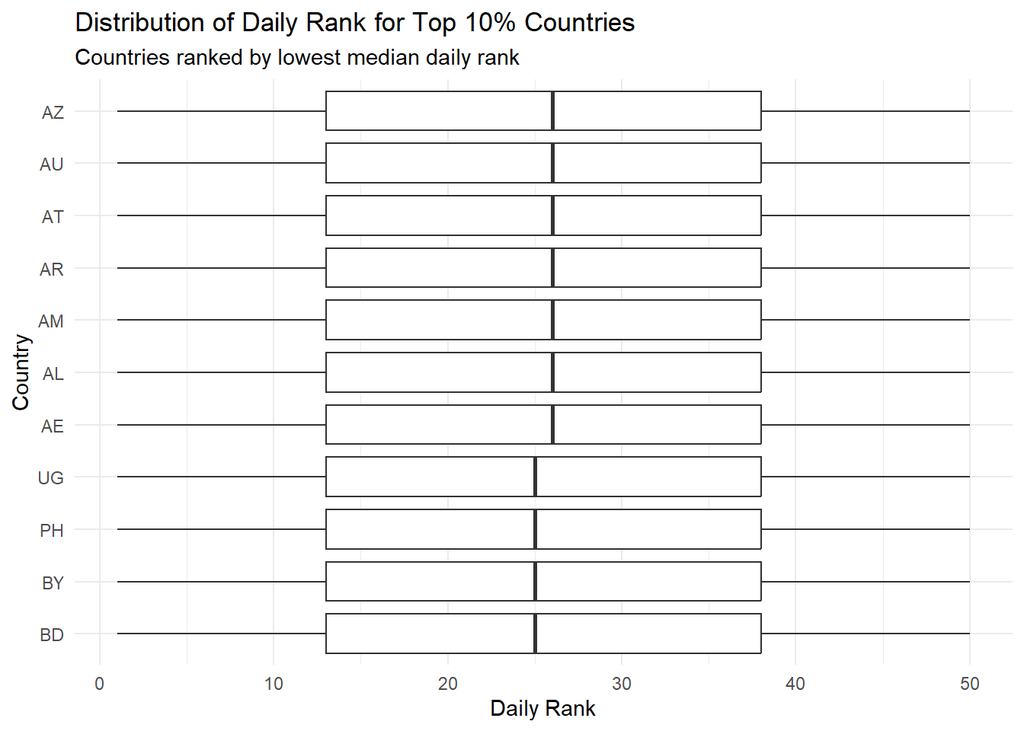

```r
# 1. Calculate the median daily_rank and total video count for each country
country_summary <- yt_df %>%
  group_by(country) %>%
  summarise(
    median_rank = median(daily_rank, na.rm = TRUE),
    video_count = n()
  ) %>%
  arrange(median_rank)

# 2. Determine the number of countries that represent the top 10%
num_top_countries <- round(0.10 * nrow(country_summary))

# 3. Select the top 10% countries based on lowest median daily_rank
top_countries <- country_summary %>%
  head(num_top_countries) %>%
  pull(country)

# 4. Filter the original dataframe to include only the top countries
df_filtered <- yt_df %>%
  filter(country %in% top_countries)

# 5. Create a boxplot for each country
ggplot(df_filtered, aes(x = reorder(country, daily_rank, FUN = median), y = daily_rank)) +
  geom_boxplot() +
  coord_flip() +
  labs(title = "Distribution of Daily Rank for Top 10% Countries",
       subtitle = "Countries ranked by lowest median daily rank",
       x = "Country",
       y = "Daily Rank") +
  theme_minimal()
```

This boxplot visualization of the top 10% of countries confirms that daily_rank is calculated within each country, not globally. Given that the daily rank ranges from 0 to 50 within countries, it’s intuitive that the median sits around 25. This supports the common industry understanding that YouTube trends are often localized, with algorithms tailoring recommendations based on the viewer’s region.

Next, we take a broader view by identifying the top 10% of countrie**s** based on three different performance metrics:

1. Average view count
2. Median like count
3. Total number of videos

```r
num_top_countries <- round(0.10 * n_distinct(yt_df$country))

# 1. Top 10% countries by highest average view count
top_avg_view_count <- yt_df %>%
  group_by(country) %>%
  summarise(avg_view_count = mean(view_count, na.rm = TRUE)) %>%
  arrange(desc(avg_view_count)) %>%
  slice_head(n = num_top_countries) %>%
  pull(country)

# 2. Top 10% countries by highest average total like count
top_avg_like_count <- yt_df %>%
  group_by(country) %>%
  summarise(total_like_count = median(like_count, na.rm = TRUE)) %>%
  arrange(desc(total_like_count)) %>%
  slice_head(n = num_top_countries) %>%
  pull(country)


# 3. Top 10% countries by highest total video count
top_video_count <- yt_df %>%
  group_by(country) %>%
  summarise(video_count = n()) %>%
  arrange(desc(video_count)) %>%
  slice_head(n = num_top_countries) %>%
  pull(country)
```

These lists help us explore whether the same countries consistently dominate across multiple measures of success. For example, a country that appears in all three lists could be a strategic focus area for content promotion.

To visualize the overlap between these three top-performing groups, we generate a Venn diagram.

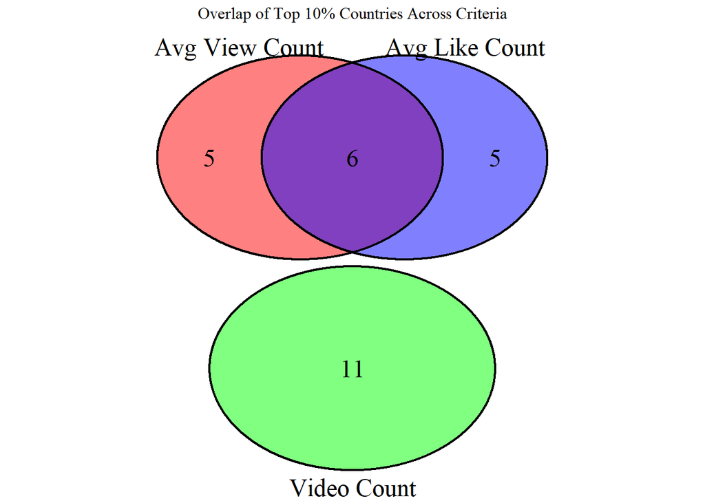

```r
list_avg_view_count <- top_avg_view_count
list_avg_like_count <- top_avg_like_count
list_video_count <- top_video_count

venn.plot <- venn.diagram(
  x = list(
    "Avg View Count" = list_avg_view_count,
    "Avg Like Count" = list_avg_like_count,
    "Video Count" = list_video_count
  ),
  filename = NULL,
  fill = c("red", "blue", "green"),
  alpha = 0.5,
  cex = 1.5,
  cat.cex = 1.5,
  cat.pos = c(-20, 20, 180),
  cat.dist = c(0.05, 0.05, 0.05),
  main = "Overlap of Top 10% Countries Across Criteria"
)

grid.newpage()
grid.draw(venn.plot)
```

It shows that out of the 11 countries in each list, 6 countries appear in both the top 10% based on average view count and average like count. However, it is interesting that no single country appears in the top 10% across all three performance metrics: average views, average likes, and total video count. This suggests that different countries excel in different aspects of video trendiness.

While the geographical analysis provided valuable insights—highlighting regional variations in daily rank and engagement patterns—we have decided not to include the `country` column in the remainder of the report. This decision is based on the assumption that our target audience, marketing industry professionals, are aiming for global reach. Therefore, their primary interest lies in identifying the overall drivers of trendiness on YouTube, regardless of geographical location. From this point forward, the focus will shift to universal predictors of video success across all countries.

```r
yt_df <- yt_df %>% select(-c("country", "full_country_name"))
```

#### 2.2. Like/View Ratio vs. Days to Trend

Objective: To analyze how the like-to-view ratio affects the time it takes for a video to trend.

Why this matters: Engagement is a strong signal for virality. Videos with high like/view ratios may be seen as higher quality or more engaging, possibly accelerating their rise to trending.

```r
# Convert dates and calculate days_to_trend
data_clean <- yt_df %>%
  # Handle different datetime formats (adjust based on your data's format)
  mutate(
    # Convert publish date (common YouTube format: "2023-01-15T14:30:15Z")
    publish_date = as.Date(ymd_hms(publish_date)),

    # Convert snapshot date (common format: "2023-01-20")
    snapshot_date = as.Date(snapshot_date),

    # Calculate days between trending and publish dates
    days_to_trend = as.numeric(snapshot_date - publish_date)
  ) %>%

  # Handle invalid date calculations
  mutate(
    days_to_trend = case_when(
      days_to_trend < 0 ~ NA_real_,   # Invalid if trending before publishing
      is.na(days_to_trend) ~ NA_real_,# Preserve existing NAs
      TRUE ~ days_to_trend
    ))
```

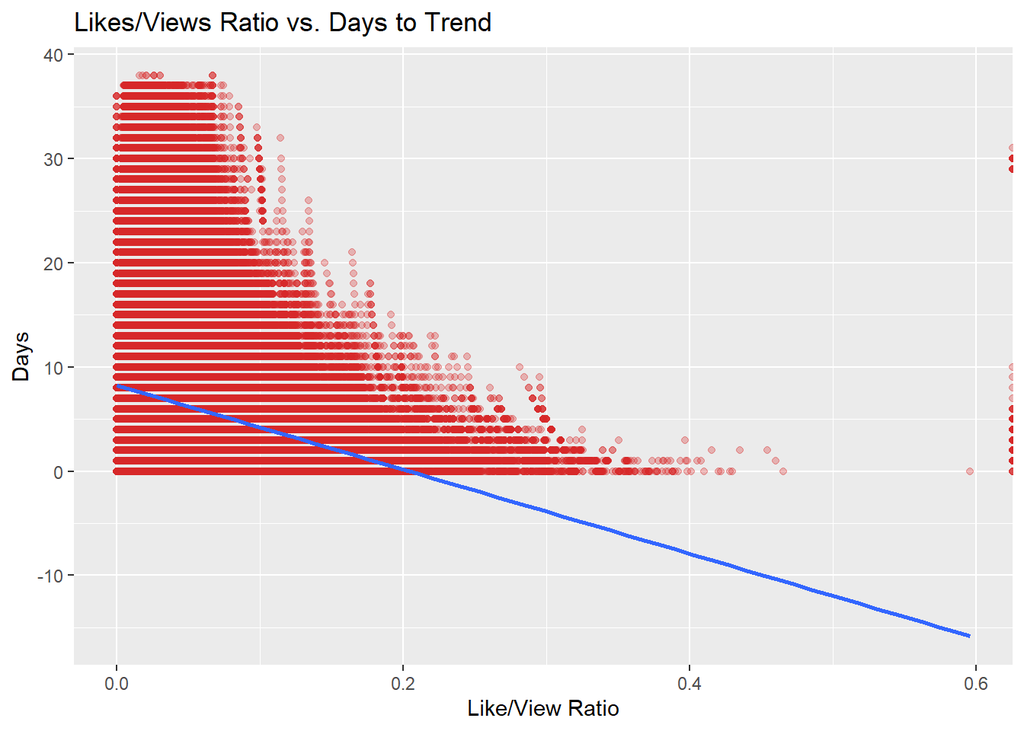

```r
# Calculate engagement ratios
data_clean <- data_clean %>%
  mutate(
    like_ratio = like_count / view_count,
    comment_ratio = comment_count / view_count,
  )

# Correlation between like_ratio and days_to_trend
ggplot(data_clean, aes(x = like_ratio, y = days_to_trend)) +
  geom_point(alpha = 0.3, color = "#d62728") +
  geom_smooth(method = "lm") +
  labs(title = "Likes/Views Ratio vs. Days to Trend", x = "Like/View Ratio", y = "Days")
```

Here, we calculate the like/view ratio as a proxy for viewer engagement. This ratio is plotted against the number of days it took the video to trend. A linear regression line is also added to observe the overall trend. There is a noticeable negative correlation: videos with a higher like/view ratio tend to trend faster. This supports the idea that engagement quality matters more than just raw view counts. The regression line slopes downward, further confirming that better audience feedback (likes) relative to views helps videos gain trending momentum more quickly.

#### 2.3. Day of Publish vs. Days to Trend

Objective: To identify whether publishing on specific days of the week affects how soon a video trends.

Why this matters: YouTube user traffic may vary by day — for example, weekends might have higher user activity. Knowing this can help with timing strategy for releasing videos.

```r
# If it's "character", re-convert dates:
data_clean <- data_clean %>%
  mutate(
    publish_date = as.Date(publish_date, format = "%Y-%m-%d")) %>%
  mutate(publish_day = weekdays(publish_date))

# Median days_to_trend by publish day
day_summary <- data_clean %>%
  group_by(publish_day) %>%
  summarise(median_days = median(days_to_trend, na.rm = TRUE))

table(data_clean$publish_day)
```

```
##
##    Friday    Monday  Saturday    Sunday  Thursday   Tuesday Wednesday
##    448707    355571    394237    383305    391777    364367    382535
```

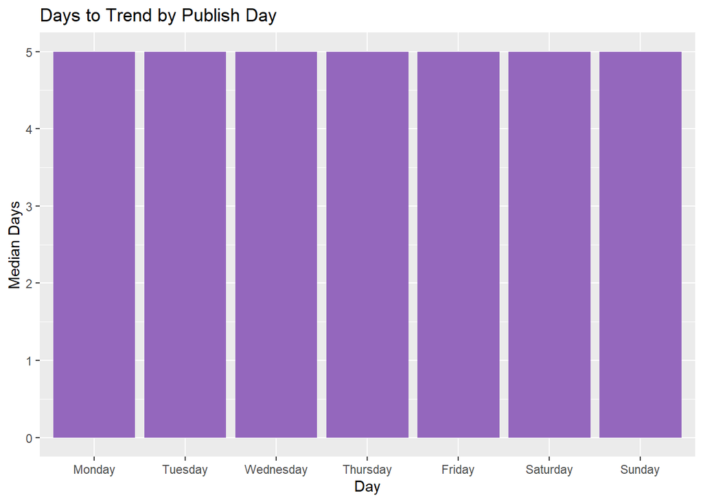

```r
ggplot(day_summary, aes(x = factor(publish_day, levels = c("Monday", "Tuesday", "Wednesday", "Thursday", "Friday", "Saturday", "Sunday")), y = median_days)) +
  geom_bar(stat = "identity", fill = "#9467bd") +
  labs(title = "Days to Trend by Publish Day", x = "Day", y = "Median Days")
```

We extract the day of the week from the video’s publish date and examine if it impacts the time taken to trend. Days are ordered from Monday to Sunday for a clean comparison. Interestingly, the median time to trend remains consistent across all days, around 5 days. This implies that publish timing does not significantly impact how quickly a video trends. It may indicate that content quality and engagement outweigh the influence of timing, at least when viewed from a weekly scale.

### 3. Outlier Identification

Next, we will check for outliers in the numerical column of our dataset. We can do this in 2 different ways. First is visually using box plots and, second, is using the IQR, where we calculate the upper and lower boundary of the column and anything outside this boundary is an outlier. Now, we will just detect if there are any outliers using the second method. *[Note: The visual inspection of outliers will be carried out during the EDA].*

We start by defining a `udf` to give us the report on the outliers based on the IQR calculation of each numerical column.

```r
detect_outliers <- function(df) {
  numeric_cols <- df %>%
    select(where(is.numeric))
  outlier_summary <- data.frame(column = character(), lower_bound = numeric(),
                                upper_bound = numeric(), num_outliers = integer(),
                                iqr = numeric(), q1 = numeric(), q3 = numeric())

  for (col in colnames(numeric_cols)) {
    q1 <- quantile(numeric_cols[[col]], 0.25, na.rm = TRUE)
    q3 <- quantile(numeric_cols[[col]], 0.75, na.rm = TRUE)
    iqr_value <- q3 - q1
    lower_limit <- q1 - 1.5 * iqr_value
    upper_limit <- q3 + 1.5 * iqr_value
    num_of_outliers <- sum(numeric_cols[[col]] < lower_limit | numeric_cols[[col]] > upper_limit, na.rm = TRUE)

    outlier_summary <- rbind(outlier_summary, data.frame(column = col, lower_bound = lower_limit,
                                                         upper_bound = upper_limit, num_outliers = num_of_outliers,
                                                         iqr = iqr_value, q1 = q1, q3 = q3))
  }
  return(outlier_summary)
}
```

```r
outlier_report <- detect_outliers(yt_df)
print(outlier_report)
```

```
##               column lower_bound upper_bound num_outliers      iqr       q1
## 25%       daily_rank       -24.5        75.5            0       25     13.0
## 25%1  daily_movement       -37.5        38.5       197298       19     -9.0
## 25%2 weekly_movement       -42.5        81.5        14120       31      4.0
## 25%3      view_count -16451376.8  28716309.2       361427 11291922 486505.5
## 25%4      like_count   -521940.5    912847.5       341592   358697  16105.0
## 25%5   comment_count     -5016.0      9472.0       332687     3622    417.0
##            q3
## 25%        38
## 25%1       10
## 25%2       35
## 25%3 11778427
## 25%4   374802
## 25%5     4039
```

Outliers are very important for us because we seek to identify trendy videos which are inherently outliers. From the outlier report results, we get a better idea of what characteristics the highest performing videos in this dataset possess. That said, we need to look carefully at this report because some of the numbers are not realistic (e.g. negative view, like, and comment counts). We will run a correlation analysis with the “desirable” outliers (trendy videos) based on these results and compare to the correlation analysis of the entire dataset.

### 4. Creating the Outlier Dataframe

Let’s create our dataframe with “desirable” outliers — in other words, the most trendy videos. Our criteria for being a trendy video is as follows:

   Rationale: Based on the outlier report, `daily_rank` Q1 = 13. We are interested in outliers in that category and go one step further to take the top 10 rankings as data for trendiness as we are looking for very special videos.
5. **Daily movement is >= -4**

   Rationale: `daily_movement` Q1 = -9 and Q3 = 10. We acknowledge trendy videos can be displaced by other trendy videos. We allow for some modest, temporary displacement in the grand scheme of the dataset.
6. **Weekly movement >= 0**

   Rationale: We are looking for videos which improve their ranking over time. A positive weekly movement means that the video is becoming progressively more popular (trendier) over time.

Let’s start by establishing the new variables expressed as ratios for criteria #1 and #2.

```r
yt_df <- yt_df %>%
  mutate(ratio_like_view = like_count / view_count)

yt_df <- yt_df %>%
  mutate(ratio_comment_view = comment_count / view_count)
```

With those ratios established, we can now filter videos according to our defined criteria. Of course, this is a simpler process because the rest of the criteria’s variables are already present in our main dataframe (criteria #3-6). Therefore, we can simply filter data by variable and add those rows to a new dataframe. We call this new dataframe `trendy_df_numeric` because in order to properly run the correlation analysis, we need data in numerical form, not character. There will be characters in this dataframe, but we will convert them in the next section when before we begin the correlation analysis.

```r
trendy_df_numeric <- yt_df %>%
  filter(
    # Criteria 1
    ratio_like_view >= quantile(ratio_like_view, 0.05, na.rm = TRUE),
    # Criteria 2
    ratio_comment_view >= quantile(ratio_comment_view, 0.05, na.rm = TRUE),
    # Criteria 3
    view_count >= quantile(view_count, 0.75, na.rm = TRUE),
    # Criteria 4
    daily_rank >= 1 & daily_rank <= 10,
    # Criteria 5
    daily_movement >= -4,
    # Criteria 6
    weekly_movement >= 0
  )
```

Great! We now have a dataframe with videos trending according to our criteria.

### 5. Principal Component Analysis

We can now begin the PCA. First thing’s first, though: we need to convert non-numeric columns to numeric. Just to confirm, let’s identify which columns are non-numeric and need to be converted.

```r
str(trendy_df_numeric)
```

```
## 'data.frame':    116357 obs. of  12 variables:
##  $ title             : chr  "Reach the Money, Win $10,000" "Kendrick Lamar's Apple Music Super Bowl Halftime Show" "Who's gonna pop the balloon first?" "Lo que el blower se llevó 😂😂😂" ...
##  $ daily_rank        : int  8 1 2 3 5 6 10 1 2 8 ...
##  $ daily_movement    : int  -1 3 3 22 -1 1 -3 0 10 17 ...
##  $ weekly_movement   : int  42 2 48 47 45 44 40 0 21 42 ...
##  $ snapshot_date     : chr  "2025-02-20" "2025-02-20" "2025-02-20" "2025-02-20" ...
##  $ view_count        : int  88610239 75930862 31928039 24372725 14741379 88610239 49676673 24236373 82507699 24372725 ...
##  $ like_count        : int  3509581 2735276 1735391 470544 762460 3509539 1450005 393618 1197865 470522 ...
##  $ comment_count     : int  4820 161202 1311 836 2789 4820 3791 22555 4573 836 ...
##  $ video_tags        : chr  NA "NFL, Football, American Football, sport, sports" NA NA ...
##  $ publish_date      : chr  "2025-02-14 00:00:00+00:00" "2025-02-10 00:00:00+00:00" "2025-02-15 00:00:00+00:00" "2025-02-10 00:00:00+00:00" ...
##  $ ratio_like_view   : num  0.0396 0.036 0.0544 0.0193 0.0517 ...
##  $ ratio_comment_view: num  5.44e-05 2.12e-03 4.11e-05 3.43e-05 1.89e-04 ...
```

We can see that the following columns are non-numeric.

1. `title`
2. `snapshot_date`
3. `publish_date`
4. `video_tags`

Because `snapshot_date` is the same for all videos, we can drop that column. We will also drop `video_tags` as that column will be explored in a separate section.

Let’s convert `title` and `publish_date` to numeric:

```r
#title
trendy_df_numeric$title_numeric <- as.numeric(factor(trendy_df_numeric$title))

#publish_date
trendy_df_numeric$date_numeric <- as.numeric(format(ymd_hms(trendy_df_numeric$publish_date), "%Y%m%d"))
```

With these converted to numeric, we need also to remove the original character versions of these columns in addition to `snapshot_date` and `video_tags`.

```r
trendy_df_numeric <- trendy_df_numeric %>% select(-c(title, publish_date, video_tags, snapshot_date))
```

```r
trendy_df_numeric <- trendy_df_numeric %>% select(-c(ratio_like_view, ratio_comment_view))
```

Let’s drop any nulls and double check that we are set on that front.

```r
trendy_df_numeric <- trendy_df_numeric %>% drop_na()
colSums(is.na(trendy_df_numeric))
```

```
##      daily_rank  daily_movement weekly_movement      view_count      like_count
##               0               0               0               0               0
##   comment_count   title_numeric    date_numeric
##               0               0               0
```

With no more nulls and all columns being numeric, relevant and of appropriate values, we can standardize our trendy dataset.

```r
trendy_standardized <- scale(trendy_df_numeric[, !names(trendy_df_numeric) %in% "classe" ], center = TRUE, scale = TRUE)
summary(trendy_standardized)
```

```
##    daily_rank       daily_movement    weekly_movement     view_count
##  Min.   :-1.46552   Min.   :-1.2563   Min.   :-2.6992   Min.   :-0.9355
##  1st Qu.:-0.76165   1st Qu.:-0.8092   1st Qu.: 0.1376   1st Qu.:-0.7155
##  Median :-0.05778   Median :-0.2876   Median : 0.4213   Median :-0.3488
##  Mean   : 0.00000   Mean   : 0.0000   Mean   : 0.0000   Mean   : 0.0000
##  3rd Qu.: 0.99803   3rd Qu.: 0.5321   3rd Qu.: 0.6340   3rd Qu.: 0.3855
##  Max.   : 1.70190   Max.   : 2.6931   Max.   : 0.7759   Max.   :10.2332
##    like_count      comment_count     title_numeric       date_numeric
##  Min.   :-1.0116   Min.   :-0.3652   Min.   :-1.68932   Min.   :-2.18229
##  1st Qu.:-0.6530   1st Qu.:-0.3473   1st Qu.:-0.86280   1st Qu.:-0.03790
##  Median :-0.3399   Median :-0.3125   Median :-0.00469   Median : 0.05262
##  Mean   : 0.0000   Mean   : 0.0000   Mean   : 0.00000   Mean   : 0.00000
##  3rd Qu.: 0.3023   3rd Qu.:-0.1696   3rd Qu.: 0.85441   3rd Qu.: 0.12486
##  Max.   : 5.9125   Max.   :10.6235   Max.   : 1.79448   Max.   : 2.22811
```

The trendy dataset (`trendy_standardized`) is now ready for PCA.

Let’s quickly prepare the full dataset for PCA so we can compare the results side-by-side. Since we will be dropping columns and converting others, let’s create a new dataframe for us to work in specifically for the PCA.

```r
full_df_numeric <- yt_df
```

First, we convert the same columns to numeric: `title` and `publish_date`.

```r
#title
full_df_numeric$title_numeric <- as.numeric(factor(full_df_numeric$title))

#publish_date
full_df_numeric$date_numeric <- as.numeric(format(ymd_hms(full_df_numeric$publish_date), "%Y%m%d"))
```

We then drop the same columns so we have the same variables as `trendy_standardized`.

```r
full_df_numeric <- full_df_numeric %>% select(-c(title, publish_date, video_tags, snapshot_date, ratio_like_view, ratio_comment_view))
```

Let’s check for nulls and drop any that arise.

```r
colSums(is.na(full_df_numeric))
```

```
##      daily_rank  daily_movement weekly_movement      view_count      like_count
##               0               0               0               0               0
##   comment_count   title_numeric    date_numeric
##               0               0               0
```

```r
full_df_numeric <- full_df_numeric %>% drop_na()
colSums(is.na(full_df_numeric))
```

```
##      daily_rank  daily_movement weekly_movement      view_count      like_count
##               0               0               0               0               0
##   comment_count   title_numeric    date_numeric
##               0               0               0
```

Nice. We are now in a position to standardize.

```r
full_standardized <- scale(full_df_numeric[, !names(full_df_numeric) %in% "classe" ], center = TRUE, scale = TRUE)
```

Now, we have two standardized dataframes: `trendy_standardized` for the trendy/outliers and `full_standardized` for the full dataset. Now, the moment you have all been waiting for: the PCA!

```r
cat("\n====================== Principal Component Analysis of trendy_standardized =====================\n\n")
```

```
##
## ====================== Principal Component Analysis of trendy_standardized =====================
```

```r
results_trendy <- prcomp(trendy_standardized)
summary(results_trendy)
```

```
## Importance of components:
##                          PC1    PC2    PC3    PC4    PC5     PC6     PC7
## Standard deviation     1.494 1.1592 1.0596 0.9882 0.9579 0.86247 0.73368
## Proportion of Variance 0.279 0.1680 0.1403 0.1221 0.1147 0.09298 0.06729
## Cumulative Proportion  0.279 0.4469 0.5873 0.7093 0.8240 0.91703 0.98432
##                            PC8
## Standard deviation     0.35419
## Proportion of Variance 0.01568
## Cumulative Proportion  1.00000
```

```r
cat("\n================================================================================================\n")
cat("\n====================== Principal Component Analysis of full_standardized =======================\n\n")
```

```
##
## ====================== Principal Component Analysis of full_standardized =======================
```

```r
results_full <- prcomp(full_standardized)
summary(results_full)
```

```
## Importance of components:
##                           PC1    PC2    PC3    PC4     PC5     PC6     PC7
## Standard deviation     1.5225 1.4125 1.0097 0.9913 0.88578 0.76352 0.44857
## Proportion of Variance 0.2898 0.2494 0.1274 0.1228 0.09808 0.07287 0.02515
## Cumulative Proportion  0.2898 0.5392 0.6666 0.7894 0.88751 0.96038 0.98553
##                            PC8
## Standard deviation     0.34022
## Proportion of Variance 0.01447
## Cumulative Proportion  1.00000
```

```r
cat("\n================================================================================================\n")
```

For both datasets, 6 principal components comprise >91% of the cumulative variance. The `full_standardized` set reaches 90% slightly before `trendy_standardized`, however. Let’s take a look at the component loadings for the PCAs for a more comprehensive view.

```r
cat("\n====================== Principal Component Loadings: trendy_standardized ===================\n\n")
```

```
##
## ====================== Principal Component Loadings: trendy_standardized ===================
```

```r
print(results_trendy$rotation)
```

```
##                         PC1         PC2         PC3         PC4         PC5
## daily_rank      -0.15244945 -0.55516397 -0.39399466 -0.28251084 -0.11965051
## daily_movement  -0.02071634  0.31684488 -0.48039681  0.33583055  0.69648313
## weekly_movement -0.25966288  0.59769289  0.24988692 -0.02559486 -0.24151159
## view_count       0.56683448 -0.20592455  0.18744694  0.11822451  0.17122911
## like_count       0.63050922  0.01973325  0.07083029  0.03500800 -0.01367483
## comment_count    0.39796419  0.33150346 -0.13442710 -0.09511163 -0.34577686
## title_numeric   -0.11981323 -0.23502146  0.09055403  0.88028500 -0.32830027
## date_numeric    -0.13164834 -0.16199245  0.69650533 -0.08717722  0.43060195
##                         PC6         PC7         PC8
## daily_rank      -0.45751238 -0.45797846  0.01139607
## daily_movement  -0.24012614 -0.11286303  0.01138060
## weekly_movement -0.11127333 -0.66144290  0.06343118
## view_count       0.17168841 -0.37398798  0.62331135
## like_count      -0.07467985 -0.25617474 -0.72417999
## comment_count   -0.61658492  0.35332887  0.28290139
## title_numeric   -0.19632421 -0.01493348 -0.02758099
## date_numeric    -0.51659069  0.09723244 -0.04437895
```

```r
cat("\n============================================================================================\n")
cat("\n====================== Principal Component Loadings: full_standardized =====================\n\n")
```

```
##
## ====================== Principal Component Loadings: full_standardized =====================
```

```r
print(results_full$rotation)
```

```
##                         PC1           PC2           PC3           PC4
## daily_rank       0.43714381  0.4503575798  0.0600476889 -0.0009351094
## daily_movement  -0.39658576 -0.3237744658  0.0002852783  0.0134071200
## weekly_movement -0.50472147 -0.3082257596 -0.0007848155  0.0074479606
## view_count       0.41386516 -0.4479459537 -0.1139145328  0.0287841363
## like_count       0.41838306 -0.5048532006 -0.0386694686  0.0428128192
## comment_count    0.22177740 -0.3676800325  0.1492852829  0.0735627206
## title_numeric   -0.03306436  0.0813884246 -0.5253621277  0.8437783217
## date_numeric     0.01655429  0.0001146705 -0.8268193686 -0.5288942319
##                         PC5         PC6          PC7          PC8
## daily_rank       0.06128011 -0.25795780  0.728253655  0.042730243
## daily_movement  -0.16792053 -0.82714038  0.159160490  0.004408293
## weekly_movement  0.10274273  0.46670603  0.646968060  0.057085695
## view_count      -0.41353876  0.07659646  0.061307221  0.658494576
## like_count      -0.14480586  0.04950777  0.136531334 -0.724354907
## comment_count    0.85345101 -0.14336978 -0.051743900  0.190571916
## title_numeric    0.06301769 -0.01457481  0.004082193 -0.010729992
## date_numeric     0.18209467 -0.04895609  0.025561803 -0.012569445
```

```r
cat("\n============================================================================================\n")
```

Optional: sort variable loadings by absolute value for each PC. This will generate a large table but does make the loading distribution easier to scan through when looking for the most influential variables in each PC.

```r
loadings_trendy <- results_trendy$rotation

cat("\n====================== Principal Component Loadings: trendy_standardized ===================\n")
```

```
##
## ====================== Principal Component Loadings: trendy_standardized ===================
```

```r
for (pc in colnames(loadings_trendy)) {
  cat("\n=========================================")
  cat("\nTop contributors to", pc, ":\n")
  print(sort(abs(loadings_trendy[, pc]), decreasing = TRUE))
}
```

```
##
## =========================================
## Top contributors to PC1 :
##      like_count      view_count   comment_count weekly_movement      daily_rank
##      0.63050922      0.56683448      0.39796419      0.25966288      0.15244945
##    date_numeric   title_numeric  daily_movement
##      0.13164834      0.11981323      0.02071634
##
## =========================================
## Top contributors to PC2 :
## weekly_movement      daily_rank   comment_count  daily_movement   title_numeric
##      0.59769289      0.55516397      0.33150346      0.31684488      0.23502146
##      view_count    date_numeric      like_count
##      0.20592455      0.16199245      0.01973325
##
## =========================================
## Top contributors to PC3 :
##    date_numeric  daily_movement      daily_rank weekly_movement      view_count
##      0.69650533      0.48039681      0.39399466      0.24988692      0.18744694
##   comment_count   title_numeric      like_count
##      0.13442710      0.09055403      0.07083029
##
## =========================================
## Top contributors to PC4 :
##   title_numeric  daily_movement      daily_rank      view_count   comment_count
##      0.88028500      0.33583055      0.28251084      0.11822451      0.09511163
##    date_numeric      like_count weekly_movement
##      0.08717722      0.03500800      0.02559486
##
## =========================================
## Top contributors to PC5 :
##  daily_movement    date_numeric   comment_count   title_numeric weekly_movement
##      0.69648313      0.43060195      0.34577686      0.32830027      0.24151159
##      view_count      daily_rank      like_count
##      0.17122911      0.11965051      0.01367483
##
## =========================================
## Top contributors to PC6 :
##   comment_count    date_numeric      daily_rank  daily_movement   title_numeric
##      0.61658492      0.51659069      0.45751238      0.24012614      0.19632421
##      view_count weekly_movement      like_count
##      0.17168841      0.11127333      0.07467985
##
## =========================================
## Top contributors to PC7 :
## weekly_movement      daily_rank      view_count   comment_count      like_count
##      0.66144290      0.45797846      0.37398798      0.35332887      0.25617474
##  daily_movement    date_numeric   title_numeric
##      0.11286303      0.09723244      0.01493348
##
## =========================================
## Top contributors to PC8 :
##      like_count      view_count   comment_count weekly_movement    date_numeric
##      0.72417999      0.62331135      0.28290139      0.06343118      0.04437895
##   title_numeric      daily_rank  daily_movement
##      0.02758099      0.01139607      0.01138060
```

```r
loadings_full <- results_full$rotation

cat("\n====================== Principal Component Loadings: full_standardized ===================\n")
```

```
##
## ====================== Principal Component Loadings: full_standardized ===================
```

```r
for (pc in colnames(loadings_full)) {
  cat("\n=========================================")
  cat("\nTop contributors to", pc, ":\n")
  print(sort(abs(loadings_full[, pc]), decreasing = TRUE))
}
```

```
##
## =========================================
## Top contributors to PC1 :
## weekly_movement      daily_rank      like_count      view_count  daily_movement
##      0.50472147      0.43714381      0.41838306      0.41386516      0.39658576
##   comment_count   title_numeric    date_numeric
##      0.22177740      0.03306436      0.01655429
##
## =========================================
## Top contributors to PC2 :
##      like_count      daily_rank      view_count   comment_count  daily_movement
##    0.5048532006    0.4503575798    0.4479459537    0.3676800325    0.3237744658
## weekly_movement   title_numeric    date_numeric
##    0.3082257596    0.0813884246    0.0001146705
##
## =========================================
## Top contributors to PC3 :
##    date_numeric   title_numeric   comment_count      view_count      daily_rank
##    0.8268193686    0.5253621277    0.1492852829    0.1139145328    0.0600476889
##      like_count weekly_movement  daily_movement
##    0.0386694686    0.0007848155    0.0002852783
##
## =========================================
## Top contributors to PC4 :
##   title_numeric    date_numeric   comment_count      like_count      view_count
##    0.8437783217    0.5288942319    0.0735627206    0.0428128192    0.0287841363
##  daily_movement weekly_movement      daily_rank
##    0.0134071200    0.0074479606    0.0009351094
##
## =========================================
## Top contributors to PC5 :
##   comment_count      view_count    date_numeric  daily_movement      like_count
##      0.85345101      0.41353876      0.18209467      0.16792053      0.14480586
## weekly_movement   title_numeric      daily_rank
##      0.10274273      0.06301769      0.06128011
##
## =========================================
## Top contributors to PC6 :
##  daily_movement weekly_movement      daily_rank   comment_count      view_count
##      0.82714038      0.46670603      0.25795780      0.14336978      0.07659646
##      like_count    date_numeric   title_numeric
##      0.04950777      0.04895609      0.01457481
##
## =========================================
## Top contributors to PC7 :
##      daily_rank weekly_movement  daily_movement      like_count      view_count
##     0.728253655     0.646968060     0.159160490     0.136531334     0.061307221
##   comment_count    date_numeric   title_numeric
##     0.051743900     0.025561803     0.004082193
##
## =========================================
## Top contributors to PC8 :
##      like_count      view_count   comment_count weekly_movement      daily_rank
##     0.724354907     0.658494576     0.190571916     0.057085695     0.042730243
##    date_numeric   title_numeric  daily_movement
##     0.012569445     0.010729992     0.004408293
```

**PCA Insights:**

Taking a look at the variable contributions to each Principal Component, we deduce the following:

**Interpretations:**

- The trendy dataset presents a more concentrated pattern as engagement and movement metrics were central in the PCs. This suggests a tighter profile of metrics to consider when aiming to predict virality.
- In contrast, the full dataset’s PC loadings were more varied which makes it challenging to predict virality based on this larger dataset.

## Feature Engineering/Selection

We have completed our EDA and now we have understood the dataset completely. We can now create features (or update the existing columns) that will be fed as inputs to the model. There can be various methods of feature engineering such as selecting the important columns or creating new columns by merging (or using any other logic) the existing columns.

### 1. Convert Text Columns into Numerical Columns

First, we would start by converting the text columns (`title` and `video_tags`, in our case) into numerical columns, for better model predictability. We would be introducing the `scores` of the said columns using the following logic (`title_score` and `video_tags_score` columns). Take the value in the cell—say 1st cell of `title` or `video_tags` column (“*Highlights Real Madrid vs Barcelona 3-1…*”)—and run the words separately through the list of words in `final_title_words` (or `final_tag_words`) and increase the count by 1 every time the word in the cell matches a word in the list. Example: The title “*Highlights Real Madrid vs Barcelona 3-1…“* will get a score of **3.**

```r
calculate_title_score <- function(title, word_list) {
  words <- tokenize(title)
  matches <- sapply(words, function(word) {
    any(grepl(paste0("\\b", word, "\\b"), word_list, ignore.case = TRUE))
  })
  # Ensure matches is a numeric vector (TRUE -> 1, FALSE -> 0)
  score <- sum(as.numeric(matches))
  return(as.integer(score))
}
```

```r
yt_df <- yt_df %>%
  mutate(title_score = vapply(title, calculate_title_score, FUN.VALUE = integer(1), word_list = final_title_words))

yt_df <- yt_df %>%
  mutate(video_tag_score = vapply(video_tags, calculate_title_score, FUN.VALUE = integer(1), word_list = final_tag_words))
```

This functions have added a column with the intended purpose. We will be using the synthetic columns inplace of the original text columns while training the model.

### 2. Creating other feature columns

Let’s prep the data for that can be fed into the model. We will be creating a few additional columns such as `engagement_score`, `comment_score`, `video_age`, and the target column itself - `trending`. The formula used for the columns are as follows:

- `engagement_score` = `like_count` / `view_count` *[Out of the total audience (people who view the video) how many people are liking the video?]*
- `comment_score` = `comment_count` / `view_count` *[Out of the total audience (people who view the video) how many people are liking the video?]*
- `video_age` = `snapshot_date` - `publish_date` *[Age of the video from the date it was uploaded to the date when this data was downloaded]*

```r
yt_df <- yt_df %>%
  mutate(
    engagement_score = ifelse(!is.na(view_count) & view_count > 0,
                              round(like_count / view_count, 2), 0),
    comment_score = ifelse(!is.na(view_count) & view_count > 0,
                           round(comment_count / view_count, 2), 0),
    video_age = as.numeric(difftime(snapshot_date, publish_date, units = "days"))
  )
```

To create the target variable (`trending`) - we start by calculating the `trend_score`. In simple words, the video that gets a `trend_score` of more than 80 (out of 100) will be considered as the positive class (`trending = 1`). The logic to calculate `trend_score` is as follows

```r
calculate_trend_score <- function(df) {
  df <- df %>%
    mutate(
      # Calculate rank-based score (50% weightage)
      rank_score = ifelse(daily_rank < 10, (10 - daily_rank) / 10, 0),

      max_movement = max(daily_movement, na.rm = TRUE),
      movement_score = ifelse(daily_movement > 0 & max_movement > 0,
                              daily_movement / max_movement, 0),

      weighted_rank_score = 0.5 * (rank_score + movement_score) * 100,

      # Engagement-based score (50% weightage)
      weighted_engagement_score = ifelse(engagement_score > 0.1, 50, 0),

      # Compute final trend_score
      trend_score = (weighted_rank_score * 0.5) + weighted_engagement_score,

      # Determine if the video is trending
      trending = ifelse(trend_score > 80, 1, 0)
    ) %>%
    select(-rank_score, -max_movement, -movement_score, -weighted_rank_score, -weighted_engagement_score)

  return(df)
}
```

```r
yt_df <- calculate_trend_score(yt_df)
```

#### Export Dataset (Optional)

## Model Training

Now that we have prepared our dataset (under the name `yt_df`), we can go ahead and select the appropriate models to classify wheter a video will become trendy. Since this is a binary classification problem (trendy vs not trendy), we selected models well-suited for this task.

First, we chose RandomForest. This ensemble method is known for its good performance on classification problems due to its ability to handle non-linear relationships, reduce overfitting through bagging, and provide insights via feature importance. It is also relative robust to noise in the data. We briefly considered Gradient Boosting, which builds models sequentially to correct errors from previous models. However, given our current goal of establishing an interpretable baseline, we decided to start with RandomForest due to its simplicity and faster training time.

Additionally, we selected Logistic Regression. It is a widely used baseline for binary classification, it offers good interpretability. Logistic regression is similar to linear regression but instead it is used with a categorical response (trendy or not trendy).

### 1. RandomForest

#### Import Dataset (Optional)

```r
# Update this variable with the your own filepath
# data_filepath <- "./datasets/trending_yt_videos_113_countries_model_training.csv"

#Import dataset
# yt_df <- read.csv(data_filepath)
```

#### 1.1 Prepping the data

In this section, we will be prepping the dataset even more, to be fed into the model. Like defining the `feature` and `target` variables, and `train-validation` split.

```r
# setting the default seed to train a reproducable model
set.seed(123)

# Defining the feature and target variables
features <- c("title_score","video_tag_score","engagement_score","comment_score","video_age")
target <- "trending"

# formula to be passed into the model(s)
formula <- as.formula(paste(target, "~", paste(features, collapse = "+")))

# Convert to a factor with valid labels
yt_df[[target]] <- factor(yt_df[[target]],
                          levels = c(0, 1),
                          labels = c("No", "Yes")
                          )
```

```r
# spliting the data into train and validation sets
split <- initial_split(yt_df, prop = 0.9, strata = target)
train_data <- training(split)
val_data <- testing(split)

# splitting the data to be used for final validation
X_val <- val_data[, features]
y_val <- val_data[, target]
```

First, we will define the `cross-validation` parameters and then proceed with `hyperparameter tuning`

```r
# cross validation
train_control <- trainControl(method="repeatedcv",
                              number=5,
                              repeats=3,
                              savePredictions = "final",
                              classProbs = TRUE,
                              summaryFunction = twoClassSummary,
                              sampling = "smote")
```

#### 1.2. Model Training

Now, that we have the data in the proper required format, we can start defining the model and train it.

> *Note - We have commented this piece of code as it was throwing error while knitting. Since, we couldn’t run everything from a single notebook (or) with different notebooks in a single run, we have separated the model training section to a different notebook. But we have added screenshots from that run in-place of the actual output.*

```r
# (Optional) manual hyperparameter tuning
# add tuneGrid = tune_grid into rf_model to use this
# tune_grid <- expand.grid(
#  mtry = c(2, 3, 4, 5),
#  splitrule = c("gini", "extratrees"),
#  min.node.size = c(1, 3, 5),
#  num.trees = c(100, 150, 200, 250, 300, 500, 750, 1000)
#  )

# random forest model - commenting for knitting purposes
# rf_model <- train(
#  formula,
#  data = train_data,
#  method = "rf",
#  metric = "ROC",
#  trControl = train_control,
#  ntree=100,
#  tuneLength = 10, # automated hyperparameter tuning
#  importance = TRUE
#  )
```

#### 1.3. Model Parameters

Now, that we have our model trained with the training data (including cross-validation and hyperparameter tuning). Let’s go ahead and check the model parameters. We will also have an option to export the model into a `.RData` file, so that it can be used in the future.

```r
# full model details
# final_rf <- rf_model$finalModel

# saving the model for future use
# save(rf_model, file = "rf_model.RData")
```

Now, let’s check the importance of each feature that we have sent as input to the model in predicting each of the target class.

- **No / Yes**: This column might represent whether the feature was used in the model (or some version of feature selection).
- **MeanDecreaseAccuracy**: This measures how much **model accuracy** decreases when the feature is **excluded** from the model. The higher the value, the more important the feature is to the model’s performance. If you exclude a feature with a high MeanDecreaseAccuracy, the accuracy of the model will drop significantly
- **MeanDecreaseGini**: This measures how much the **Gini impurity** (a measure of node purity) is reduced when the feature is used to split the trees. Higher values indicate more important features, as they lead to splits that significantly reduce impurity in the decision trees. Features with high MeanDecreaseGini contribute more to the model’s ability to separate classes.

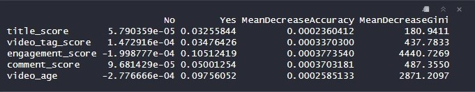

Random Forest - Feature Importance

#### 1.4. Performance Evaluation

First, let’s start with understanding the importance of each feature as per the model.

```r
# to get feature importance
# print(final_rf$importance)

# plot the feature importance for better visualization
# importance_df <- data.frame(Feature = rownames(final_rf$importance),
#                            Importance = final_rf$importance[, 2])

# ggplot(importance_df,
#       aes(x = reorder(Feature, Importance), y = Importance)) +
#  geom_bar(stat = "identity") +
#  coord_flip() +
#  theme_minimal() +
#  labs(title = "Feature Importance in RF Model", x = "Feature", y = "Importance")
```

Here, we can see that `title_score`, `video_tag_score` are relatively less important than the `engagement_score`, `video_age` and `comment_score` in predicting the video’s trendiness.

Now, we are going to use the trained model to predict some unseen data. This will help us understand the actual performance of the model in the real-world where it will come across new data from time to time.

```r
# Predict on your validation set
# pred_class <- predict(final_rf, newdata = X_val)

# Confusion matrix
# confusionMatrix(pred_class, y_val)
```

[figure not shown]

Random Forest - Confusion Matrix

As we can see from the confusion matrix, the Random Forest model has pretty high `accuracy (~ 99.48%)` - *sounds like an overfitted model* - But this is okay, since the count of positive class is very low compared to the negative class. We have used the cross-validation and hyperparameter tuning while training the model. This should suppress the overfitting problem. Moving on to the other scores, we have got a pretty good `precision (63.82%)` meaning that our model is correctly classifying the trending videos as trending. This is something which we really want. The `Recall` and `F1 scores (~10.05% & ~17.26%)` are in the lower range which could be improved using weights for the classes.

### **2. Logistic Regression**

We will be repeating the `steps 1.2 to 1.4` for Logistic Regression.

> *Note - When running for the first time - make sure to enter “yes” in the terminal - to install the required packages*

```r
# Train logistic regression model using features NOT in label creation
logit_model <- train(
  formula,
  data = train_data,
  method = "glm",
  family = "binomial",
  trControl = train_control,
  metric = "ROC"
)
```

```r
# full model details
print(logit_model$finalModel)
```

```
##
## Call:  NULL
##
## Coefficients:
##      (Intercept)       title_score   video_tag_score  engagement_score
##        -5.698566         -0.216438         -0.006941         83.092306
##    comment_score         video_age
##         5.351951         -1.157414
##
## Degrees of Freedom: 4870065 Total (i.e. Null);  4870060 Residual
## Null Deviance:       6751000
## Residual Deviance: 1081000   AIC: 1081000
```

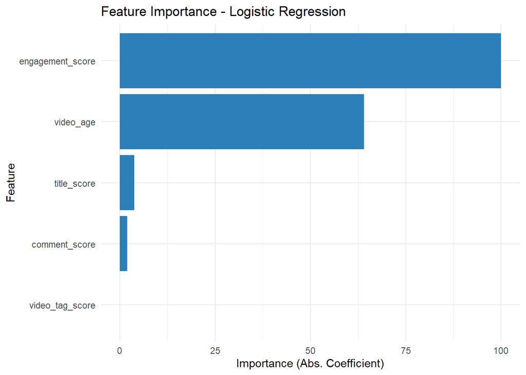

```r
# plot the feature importance for better visualization
importance <- varImp(logit_model, scale = TRUE)

importance_df <- importance$importance
importance_df$Feature <- rownames(importance_df)

importance_df %>%
  arrange(desc(Overall)) %>%
  ggplot(aes(x = reorder(Feature, Overall), y = Overall)) +
  geom_col(fill = "#2c7fb8") +
  coord_flip() +
  labs(title = "Feature Importance - Logistic Regression",
       x = "Feature",
       y = "Importance (Abs. Coefficient)") +
  theme_minimal()
```

```r
# Predict on your validation set
pred_class <- predict(logit_model, newdata = X_val)

# Confusion matrix
confusionMatrix(pred_class, y_val, positive="Yes")
```

```
## Confusion Matrix and Statistics
##
##           Reference
## Prediction     No    Yes
##        No  258823     13
##        Yes  11780   1434
##
##                Accuracy : 0.9567
##                  95% CI : (0.9559, 0.9574)
##     No Information Rate : 0.9947
##     P-Value [Acc > NIR] : 1
##
##                   Kappa : 0.1878
##
##  Mcnemar's Test P-Value : <2e-16
##
##             Sensitivity : 0.991016
##             Specificity : 0.956468
##          Pos Pred Value : 0.108521
##          Neg Pred Value : 0.999950
##              Prevalence : 0.005319
##          Detection Rate : 0.005271
##    Detection Prevalence : 0.048572
##       Balanced Accuracy : 0.973742
##
##        'Positive' Class : Yes
##
```

Based on accuracy, both the models have higher values, but we need good precision (Postive Predictive Value) and Recall (sensitivity) for our use case (i.e. reducing the number of errors (both Type 1 and Type 2) to better understand the factors that are influencing the trendiness of a video).

## Conclusion

Interestingly, our model challenges two commonly held industry assumptions:

- *Time-sensitivity* (e.g., going viral within 24–72 hours) appears to be less influential than engagement metrics.
- *Video tags,* although often emphasized in optimization strategies, show limited predictive value for trendiness compared to likes, comments, and title wording.

### Limitations

1. **Data Quality:** First, we must start by acknowledging the quality of the data. The saying goes: “garbage in, garbage out.” In this sense, we are limited to the quality of data the author of the dataset has gathered. The limitation here is that with garbage data, we cannot derive great insights. Similarly, if the data is falsified, we cannot derive realistic insights. While we have verified a handful of the videos listed in the set, we make the assumption that the rest of the set is also real data.
2. **Data Temporality:** We must also consider the temporality of the data. We started with a Kaggle dataset of trending videos downloaded on 20 February 2025. It is possible that videos trending in February 2025 do not reflect general conditions of trendiness during other periods of time. However, we believe it is reasonable to assume that our insights derived from this dataset can be safely applied to other times of the year.
3. **Dataset Contents:** This dataset contains the top 50 trending videos across 113 countries but is not specifically limited to marketing-oriented videos. Some of these videos are marketing content, others are made by content creators whose videos are marketing, in essence, as they build upon their brand. In this sense, a potential limitation of this data is that the insights may not be applicable to marketing-oriented content due to the general nature of the dataset. We acknowledge this and believe that an understanding of trendiness itself is valuable for marketing professionals and that they will be able to use these insights to boost their marketing efforts.
4. **PCA Columns:** For our PCA, we used a dataset with less dimensionality than the original. We decided to drop columns which did not have many unique values and/or could not be converted to be numeric. In doing this, we reduced our dimensionality pre-PCA to 8 columns. One limitation of this reduction is that we overlooked a column which turns out to be valuable.
5. **R Literacy:** The R-savviness of the marketing professional may limit their ability to effectively leverage this machine learning model to their advantage. We strive to make our conclusion and application section as clear as possible for those who may be unfamiliar with R, there remains the risk of misinterpretation.

### **Further Steps for Improvement**

1. **More Data:** The first step for further improvement will naturally be more data. We firmly believe in our models but testing sets of older data could provide valuable insights into how trendiness criteria have changed over time. This could entail varying user engagement and/or different content strategy. Additional datasets could deepen the understanding of trendiness by revealing larger trends which our singular dataset may not be able to capture.
2. **YouTube Shorts:** Another area of improvement would be to look at YouTube Shorts—their product which competes with TikTok and Instagram Reels. Short-form video caters to a different customers than full-length YouTube videos and thus have different strategies. Notably, the Shorts are—as the name implies—short. This means the videos need to be engaging the user extremely frequently—about every 3 seconds. A separate model to uncover Shorts trendiness would directly support marketing professionals’ expansions into the short-form video, unlocking access new customers and improved brand awareness.

## References

1. 1,800 YouTube videos are posted every minute. [https://seo.ai/blog/how-many-videos-are-on-youtube]
2. Avg human attention span was 8 seconds in 2024. [https://devrix.com/tutorial/user-attention-span/#:~:text=The%20average%20user%20attention%20span,8%20seconds%20in%20recent%20years.]

Group 12  
Keerthanapriya Kumaravel  
Liam Punselie  
Ryan Oosting  
Sabesanhari Rajamanikam  
Shalaka Deo